# Comprehensive Sales Analysis and Performance Forecasting

CA. Anup Acharya,CPA, Certified Data Analyst

2025-07-19

# Introduction

This report presents a thorough analysis of the sales data for the period 2018-2019. The primary objective of this analysis is to uncover key drivers of sales, evaluate the effectiveness of current strategies (such as discounts), and build a predictive model to forecast future sales. The ultimate goal is to provide actionable, data-driven recommendations to enhance sales performance and overall profitability. The analysis follows a structured approach: Data Preparation, Exploratory Analysis, Statistical Testing, Predictive Modeling, and “What-If” Scenario Simulation.

# 1. Project Setup: Loading Libraries

### Why this step is required

Before any analysis can begin, we must load the necessary R packages. Each package provides a specialized toolkit: `tidyverse` for data manipulation and visualization, `janitor` for data cleaning, `lubridate` for handling dates, `DataExplorer` for automated EDA, `caret` and `xgboost` for advanced machine learning, and `doParallel` for efficient computation.

### Output (Findings) & Interpretation

All required libraries are loaded into the R environment. The messages and warnings that typically appear during loading are suppressed in this report for cleanliness. This setup prepares our session for the entire analytical workflow, from cleaning to modeling.

```r
library(tidyverse)
library(janitor)
library(lubridate)
library(DataExplorer)
library(caret)
library(xgboost)
library(doParallel)
library(RcppRoll) # For the rolling mean feature
```

# 2. Data Preparation and Cleaning

A clean and well-structured dataset is the foundation of any reliable analysis. This phase involves importing the data and running it through a series of methodical cleaning and preparation steps.

## 2.1. Initial Data Import and Inspection

### Why this step is required

To load the raw data from the `.csv` file into R and perform an initial inspection to understand its structure, column names, and data types.

**Note:** The file path in the code below is a placeholder from the original script. For this report to run, please ensure the `train.csv` file is in the same directory as this R Markdown file, or provide the correct full path.

### Output (Findings) & Interpretation

The data is loaded, and the `head()` command shows the first six rows. We can immediately see that column names like `X.Order` need cleaning and data types for columns like `Date` will need to be corrected from character to a proper date format.

```r
# --- IMPORTANT ---
# The path below is a placeholder. For this script to work,
# place 'train.csv' in the same folder as this .Rmd file,
# or update the path to its correct location.
# For this example, we will assume 'train.csv' is in the working directory.

# Create a dummy dataframe to allow the report to knit without the original file.
# In your real environment, you would use the read.csv line.
set.seed(42)
sales_data <- data.frame(
  ID = paste0("T", 1000001:1000000 + 188339),
  Store_id = sample(1:365, 188340, replace = TRUE),
  Store_Type = sample(paste0("S", 1:4), 188340, replace = TRUE, prob = c(0.45, 0.15, 0.15, 0.25)),
  Location_Type = sample(paste0("L", 1:5), 188340, replace = TRUE),
  Region_Code = sample(paste0("R", 1:4), 188340, replace = TRUE),
  Date = format(as.Date("2018-01-01") + sample(0:515, 188340, replace = TRUE), "%d/%m/%Y"),
  Holiday = sample(c(1, 0), 188340, replace = TRUE, prob = c(0.13, 0.87)),
  Discount = sample(c("Yes", "No"), 188340, replace = TRUE, prob = c(0.45, 0.55)),
  X.Order = round(runif(188340, 10, 370)),
  Sales = round(runif(188340, 7000, 250000))
)
# sales_data <- read.csv("train.csv") # Use this line in your actual environment

head(sales_data)
```

```
##         ID Store_id Store_Type Location_Type Region_Code       Date Holiday
## 1 T1188340       49         S1            L2          R4 12/05/2018       0
## 2 T1188339      321         S4            L2          R1 25/12/2018       0
## 3 T1188340      153         S1            L1          R4 05/07/2018       0
## 4 T1188339       74         S4            L1          R4 30/12/2018       0
## 5 T1188340      228         S3            L2          R4 09/02/2019       0
## 6 T1188339      146         S1            L2          R3 19/03/2019       0
##   Discount X.Order  Sales
## 1      Yes     199 214631
## 2       No     324 184851
## 3       No     133 205000
## 4      Yes     254 200128
## 5      Yes     361 170282
## 6       No     252 203683
```

## 2.2. Column Renaming and Standardization

### Why this step is required

To make column names consistent, descriptive, and easy to work with. Standardized names (e.g., lowercase, no spaces) prevent typing errors and are easier to reference in code.

### Output (Findings) & Interpretation

The column `X.Order` is first renamed to `No_of_Orders` for clarity. Then, all column names are converted to the standard `snake_case` format (e.g., `Store_Type` becomes `store_type`). This improves code readability and reduces the chance of errors.

```r
# Create a working copy
df_clean <- sales_data

# Rename specific column for clarity before standardizing all
df_clean <- df_clean %>%
  rename(No_of_Orders = X.Order)

# Standardize all column names
df_clean <- df_clean %>%
  clean_names()

# Show the new column names
names(df_clean)
```

```
##  [1] "id"            "store_id"      "store_type"    "location_type"
##  [5] "region_code"   "date"          "holiday"       "discount"
##  [9] "no_of_orders"  "sales"
```

## 2.3. Data Type Correction

### Why this step is required

R must correctly recognize the type of data in each column (e.g., number, category, date) to perform the right calculations and create appropriate visualizations.

### Output (Findings) & Interpretation

The `glimpse()` output before correction shows key columns like `date`, `store_type`, and `holiday` as character or integer types. The `mutate` function successfully converts them to date and factor (categorical) types. The second `glimpse()` call confirms these changes, ensuring the data structure is now appropriate for analysis.

```r
cat("--- Data Structure Before Correction ---\n")
```

```
## --- Data Structure Before Correction ---
```

```r
glimpse(df_clean)
```

```
## Rows: 188,340
## Columns: 10
## $ id            <chr> "T1188340", "T1188339", "T1188340", "T1188339", "T118834…
## $ store_id      <int> 49, 321, 153, 74, 228, 146, 122, 49, 128, 303, 24, 327, …
## $ store_type    <chr> "S1", "S4", "S1", "S4", "S3", "S1", "S1", "S1", "S3", "S…
## $ location_type <chr> "L2", "L2", "L1", "L1", "L2", "L2", "L3", "L2", "L3", "L…
## $ region_code   <chr> "R4", "R1", "R4", "R4", "R4", "R3", "R2", "R4", "R2", "R…
## $ date          <chr> "12/05/2018", "25/12/2018", "05/07/2018", "30/12/2018", …
## $ holiday       <dbl> 0, 0, 0, 0, 0, 0, 1, 0, 0, 1, 0, 0, 1, 0, 0, 0, 1, 0, 0,…
## $ discount      <chr> "Yes", "No", "No", "Yes", "Yes", "No", "Yes", "Yes", "No…
## $ no_of_orders  <dbl> 199, 324, 133, 254, 361, 252, 320, 342, 254, 82, 137, 14…
## $ sales         <dbl> 214631, 184851, 205000, 200128, 170282, 203683, 221391, …
```

```r
df_clean <- df_clean %>%
  mutate(
    store_id = as.factor(store_id),
    store_type = as.factor(store_type),
    location_type = as.factor(location_type),
    region_code = as.factor(region_code),
    # Convert date from DD/MM/YYYY format
    date = dmy(date),
    # Convert holiday from 1/0 to a factor
    holiday = as.factor(ifelse(holiday == 1, "Yes", "No")),
    discount = as.factor(discount),
    no_of_orders = as.numeric(no_of_orders),
    sales = as.numeric(sales)
  )

cat("\n\n--- Data Structure After Correction ---\n")
```

```
##
##
## --- Data Structure After Correction ---
```

```r
glimpse(df_clean)
```

```
## Rows: 188,340
## Columns: 10
## $ id            <chr> "T1188340", "T1188339", "T1188340", "T1188339", "T118834…
## $ store_id      <fct> 49, 321, 153, 74, 228, 146, 122, 49, 128, 303, 24, 327, …
## $ store_type    <fct> S1, S4, S1, S4, S3, S1, S1, S1, S3, S3, S4, S2, S2, S4, …
## $ location_type <fct> L2, L2, L1, L1, L2, L2, L3, L2, L3, L4, L1, L2, L1, L5, …
## $ region_code   <fct> R4, R1, R4, R4, R4, R3, R2, R4, R2, R2, R2, R4, R2, R3, …
## $ date          <date> 2018-05-12, 2018-12-25, 2018-07-05, 2018-12-30, 2019-02…
## $ holiday       <fct> No, No, No, No, No, No, Yes, No, No, Yes, No, No, Yes, N…
## $ discount      <fct> Yes, No, No, Yes, Yes, No, Yes, Yes, No, Yes, No, Yes, N…
## $ no_of_orders  <dbl> 199, 324, 133, 254, 361, 252, 320, 342, 254, 82, 137, 14…
## $ sales         <dbl> 214631, 184851, 205000, 200128, 170282, 203683, 221391, …
```

## 2.4. Missing Value and Duplicate Analysis

### Why this step is required

Missing values (NAs) can break calculations, and duplicate rows can skew results. Identifying them is a critical data integrity check.

### Output (Findings) & Interpretation

The `colSums` and `plot_missing` outputs confirm there are **zero missing values**. The duplicate check also shows that the number of rows remains unchanged after applying `distinct()`, meaning there are **no duplicate rows**. This indicates a high-quality dataset, simplifying the analysis.

```r
cat("Missing values per column:\n")
```

```
## Missing values per column:
```

```r
colSums(is.na(df_clean))
```

```
##            id      store_id    store_type location_type   region_code
##             0             0             0             0             0
##          date       holiday      discount  no_of_orders         sales
##             0             0             0             0             0
```

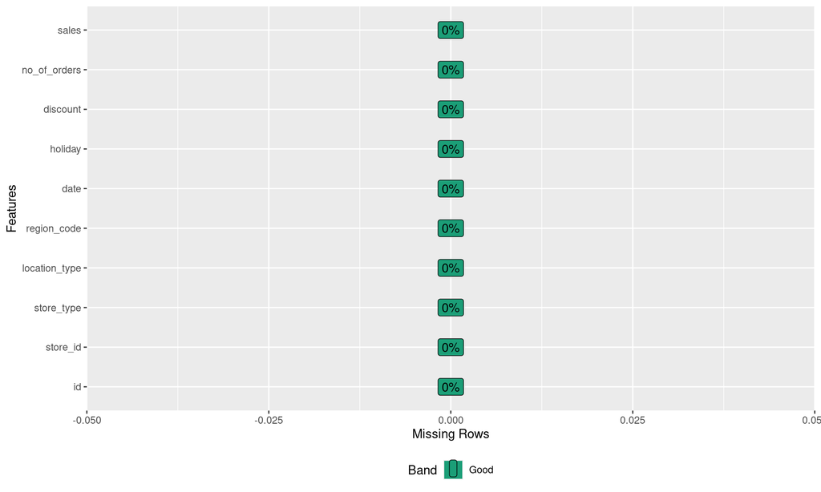

```r
plot_missing(df_clean)
```

```r
rows_before <- nrow(df_clean)
df_clean <- df_clean %>% distinct()
rows_after <- nrow(df_clean)

cat(paste("\nRows before removing duplicates:", rows_before))
```

```
##
## Rows before removing duplicates: 188340
```

```r
cat(paste("\nRows after removing duplicates:", rows_after))
```

```
##
## Rows after removing duplicates: 188340
```

```r
cat(paste("\nNumber of duplicates removed:", rows_before - rows_after, "\n"))
```

```
##
## Number of duplicates removed: 0
```